# LESSON 8: CAPSTONE PROJECT

[figure not shown]

## 1. Overall

### 1.2. Excercise 2:

Write a `function` to check input number is a prime number or a composite number.

### 1.3. Excercise 3:

Given a string `'We love Data Science. We love Python'`.

- Count each word in this string
- Filter duplicate words in this string
- Print a string which has the reverse order `'Python love We. Science Data love We'`

## 2. Numpy and Pandas

Use `seaborn` to load the `Iris dataset`.

### 2.1. Excercise 4:

Use `numpy` to solve this excercise.

- Write a function to calculate `min`, `max`, `average`, `median`, `standard deviation` of each iris feature (`sepal_length`, `sepal_width`, `petal_length`, `petal_width`)
- Use the function from above question but calculating each species separately (`versicolor`, `setosa`, `virginica`)
- For each row, calculate the `special_value` by using this fomula:  
  `special_value = (sepal_length * sepal_width - petal_length ^ petal_width) / (sepal_length + sepal_width + petal_length + petal_width)`

## 3. Matplotlib and Seaborn

Use `seaborn` to load the `Penguins dataset`. And use `pandas` to handle the `NaN` value.

### 3.1. Excercise 5:

Use both `matplotlib` and `seaborn` to plot each of following figure. All figures must have title, label and legend.

- Plot the histogram of each penguins feature (`bill_length_mm`, `bill_depth_mm`, `flipper_length_mm`, `body_mass_g`)
- Use scatter plot to show the relationship of the two features `bill_length_mm` and `bill_depth_mm` each `species`, each `island` and each `sex`. (Three separated scatter plot)
- Use bar plot to show the average value of each penguins feature (`bill_length_mm`, `bill_depth_mm`, `flipper_length_mm`, `body_mass_g`) each `species`, each `island` and each `sex`. (Three separated bar plot)

### 3.2. Excercise 6:

Use `seaborn` to plot each of following figure. All figures must have title, label and legend.

- Use box plot to show information of each penguins feature (`bill_length_mm`, `bill_depth_mm`, `flipper_length_mm`, `body_mass_g`)
- Use violin plot to show information of each penguins feature (`bill_length_mm`, `bill_depth_mm`, `flipper_length_mm`, `body_mass_g`) split by `sex`.

## Solution

### Excercise 1:

```python
from math import factorial
```

```python
def pascal_use_for(n):
    for i in range(n):
        for j in range(i+1):
            # nCr = n!/((n-r)!*r!)
            print(factorial(i)//(factorial(j)*factorial(i-j)), end=' ')
        print()
```

```python
pascal_use_for(10)
```

```
1
1 1
1 2 1
1 3 3 1
1 4 6 4 1
1 5 10 10 5 1
1 6 15 20 15 6 1
1 7 21 35 35 21 7 1
1 8 28 56 70 56 28 8 1
1 9 36 84 126 126 84 36 9 1
```

```python
def pascal_use_while(n):
    i = 0
    while i < n:
        j = 0
        while j < i + 1:
            # nCr = n!/((n-r)!*r!)
            print(factorial(i)//(factorial(j)*factorial(i-j)), end=' ')
            j += 1
        print()
        i += 1
```

```python
pascal_use_while(10)
```

```
1
1 1
1 2 1
1 3 3 1
1 4 6 4 1
1 5 10 10 5 1
1 6 15 20 15 6 1
1 7 21 35 35 21 7 1
1 8 28 56 70 56 28 8 1
1 9 36 84 126 126 84 36 9 1
```

### Excercise 2:

Write a `function` to check input number is a prime number or a composite number.

```python
def check_prime_composite(n):
    status = 'prime'

    for i in range(2, int(n / 2) + 1):
        if n % i == 0:
            print(i)
            status = 'composite'
    return status
```

```python
check_prime_composite(10)
```

```
2
5
```

```
'composite'
```

### Excercise 3:

Given a string `'We love Data Science. We love Python'`.

- Count each word in this string
- Filter duplicate words in this string
- Print a string which has the reverse order `'Python love We. Science Data love We'`

```python
stringg = 'We love Data Science. We love Python'
```

```python
words = stringg.split(' ')
words
```

```
['We', 'love', 'Data', 'Science.', 'We', 'love', 'Python']
```

```python
print(len(words))
```

```
7
```

```python
unique_words = list(set(words))
unique_words
```

```
['love', 'We', 'Data', 'Python', 'Science.']
```

```python
reversed_words = words[::-1]
reversed_words
```

```
['Python', 'love', 'We', 'Science.', 'Data', 'love', 'We']
```

```python
reversed_string = ' '.join(reversed_words)
reversed_string
```

```
'Python love We Science. Data love We'
```

### Excercise 4:

Use `numpy` to solve this excercise.

- Write a function to calculate `min`, `max`, `average`, `median`, `standard deviation` of each iris feature (`sepal_length`, `sepal_width`, `petal_length`, `petal_width`)
- Use the function from above question but calculating each species separately (`versicolor`, `setosa`, `virginica`)
- For each row, calculate the `special_value` by using this fomula:  
  `special_value = (sepal_length * sepal_width - petal_length ^ petal_width) / (sepal_length + sepal_width + petal_length + petal_width)`

```python
import seaborn as sns
```

```python
df = sns.load_dataset('iris')
df
```

|  | sepal_length | sepal_width | petal_length | petal_width | species |
| --- | --- | --- | --- | --- | --- |
| 0 | 5.1 | 3.5 | 1.4 | 0.2 | setosa |
| 1 | 4.9 | 3.0 | 1.4 | 0.2 | setosa |
| 2 | 4.7 | 3.2 | 1.3 | 0.2 | setosa |
| 3 | 4.6 | 3.1 | 1.5 | 0.2 | setosa |
| 4 | 5.0 | 3.6 | 1.4 | 0.2 | setosa |
| ... | ... | ... | ... | ... | ... |
| 145 | 6.7 | 3.0 | 5.2 | 2.3 | virginica |
| 146 | 6.3 | 2.5 | 5.0 | 1.9 | virginica |
| 147 | 6.5 | 3.0 | 5.2 | 2.0 | virginica |
| 148 | 6.2 | 3.4 | 5.4 | 2.3 | virginica |
| 149 | 5.9 | 3.0 | 5.1 | 1.8 | virginica |

150 rows × 5 columns

```python
df.describe()
```

|  | sepal_length | sepal_width | petal_length | petal_width |
| --- | --- | --- | --- | --- |
| count | 150.000000 | 150.000000 | 150.000000 | 150.000000 |
| mean | 5.843333 | 3.057333 | 3.758000 | 1.199333 |
| std | 0.828066 | 0.435866 | 1.765298 | 0.762238 |
| min | 4.300000 | 2.000000 | 1.000000 | 0.100000 |
| 25% | 5.100000 | 2.800000 | 1.600000 | 0.300000 |
| 50% | 5.800000 | 3.000000 | 4.350000 | 1.300000 |
| 75% | 6.400000 | 3.300000 | 5.100000 | 1.800000 |
| max | 7.900000 | 4.400000 | 6.900000 | 2.500000 |

```python
df.loc[df.species == 'setosa'].describe()
```

|  | sepal_length | sepal_width | petal_length | petal_width |
| --- | --- | --- | --- | --- |
| count | 50.00000 | 50.000000 | 50.000000 | 50.000000 |
| mean | 5.00600 | 3.428000 | 1.462000 | 0.246000 |
| std | 0.35249 | 0.379064 | 0.173664 | 0.105386 |
| min | 4.30000 | 2.300000 | 1.000000 | 0.100000 |
| 25% | 4.80000 | 3.200000 | 1.400000 | 0.200000 |
| 50% | 5.00000 | 3.400000 | 1.500000 | 0.200000 |
| 75% | 5.20000 | 3.675000 | 1.575000 | 0.300000 |
| max | 5.80000 | 4.400000 | 1.900000 | 0.600000 |

```python
df.loc[df.species == 'versicolor'].describe()
```

|  | sepal_length | sepal_width | petal_length | petal_width |
| --- | --- | --- | --- | --- |
| count | 50.000000 | 50.000000 | 50.000000 | 50.000000 |
| mean | 5.936000 | 2.770000 | 4.260000 | 1.326000 |
| std | 0.516171 | 0.313798 | 0.469911 | 0.197753 |
| min | 4.900000 | 2.000000 | 3.000000 | 1.000000 |
| 25% | 5.600000 | 2.525000 | 4.000000 | 1.200000 |
| 50% | 5.900000 | 2.800000 | 4.350000 | 1.300000 |
| 75% | 6.300000 | 3.000000 | 4.600000 | 1.500000 |
| max | 7.000000 | 3.400000 | 5.100000 | 1.800000 |

```python
df.loc[df.species == 'virginica'].describe()
```

|  | sepal_length | sepal_width | petal_length | petal_width |
| --- | --- | --- | --- | --- |
| count | 50.00000 | 50.000000 | 50.000000 | 50.00000 |
| mean | 6.58800 | 2.974000 | 5.552000 | 2.02600 |
| std | 0.63588 | 0.322497 | 0.551895 | 0.27465 |
| min | 4.90000 | 2.200000 | 4.500000 | 1.40000 |
| 25% | 6.22500 | 2.800000 | 5.100000 | 1.80000 |
| 50% | 6.50000 | 3.000000 | 5.550000 | 2.00000 |
| 75% | 6.90000 | 3.175000 | 5.875000 | 2.30000 |
| max | 7.90000 | 3.800000 | 6.900000 | 2.50000 |

`special_value = (sepal_length * sepal_width - petal_length ^ petal_width) / (sepal_length + sepal_width + petal_length + petal_width)`

```python
def cal_special_value(data):
    sepal_length, sepal_width, petal_length, petal_width = data[0], data[1], data[2], data[3]
    a = sepal_length * sepal_width - petal_length ** petal_width
    b = sepal_length + sepal_width + petal_length + petal_width

    return a / b
```

```python
df['special_value'] = df[['sepal_length', 'sepal_width', 'petal_length', 'petal_width']].apply(
    cal_special_value, axis=1)
```

```python
df
```

|  | sepal_length | sepal_width | petal_length | petal_width | species | special_value |
| --- | --- | --- | --- | --- | --- | --- |
| 0 | 5.1 | 3.5 | 1.4 | 0.2 | setosa | 1.645136 |
| 1 | 4.9 | 3.0 | 1.4 | 0.2 | setosa | 1.434778 |
| 2 | 4.7 | 3.2 | 1.3 | 0.2 | setosa | 1.487886 |
| 3 | 4.6 | 3.1 | 1.5 | 0.2 | setosa | 1.401652 |
| 4 | 5.0 | 3.6 | 1.4 | 0.2 | setosa | 1.659842 |
| ... | ... | ... | ... | ... | ... | ... |
| 145 | 6.7 | 3.0 | 5.2 | 2.3 | virginica | -1.409374 |
| 146 | 6.3 | 2.5 | 5.0 | 1.9 | virginica | -0.352452 |
| 147 | 6.5 | 3.0 | 5.2 | 2.0 | virginica | -0.451497 |
| 148 | 6.2 | 3.4 | 5.4 | 2.3 | virginica | -1.577003 |
| 149 | 5.9 | 3.0 | 5.1 | 1.8 | virginica | -0.068165 |

150 rows × 6 columns

### Excercise 5:

Use both `matplotlib` and `seaborn` to plot each of following figure. All figures must have title, label and legend.

```python
import matplotlib.pyplot as plt
sns.set()
```

```python
df = sns.load_dataset('penguins')
df
```

|  | species | island | bill_length_mm | bill_depth_mm | flipper_length_mm | body_mass_g | sex |
| --- | --- | --- | --- | --- | --- | --- | --- |
| 0 | Adelie | Torgersen | 39.1 | 18.7 | 181.0 | 3750.0 | Male |
| 1 | Adelie | Torgersen | 39.5 | 17.4 | 186.0 | 3800.0 | Female |
| 2 | Adelie | Torgersen | 40.3 | 18.0 | 195.0 | 3250.0 | Female |
| 3 | Adelie | Torgersen | NaN | NaN | NaN | NaN | NaN |
| 4 | Adelie | Torgersen | 36.7 | 19.3 | 193.0 | 3450.0 | Female |
| ... | ... | ... | ... | ... | ... | ... | ... |
| 339 | Gentoo | Biscoe | NaN | NaN | NaN | NaN | NaN |
| 340 | Gentoo | Biscoe | 46.8 | 14.3 | 215.0 | 4850.0 | Female |
| 341 | Gentoo | Biscoe | 50.4 | 15.7 | 222.0 | 5750.0 | Male |
| 342 | Gentoo | Biscoe | 45.2 | 14.8 | 212.0 | 5200.0 | Female |
| 343 | Gentoo | Biscoe | 49.9 | 16.1 | 213.0 | 5400.0 | Male |

344 rows × 7 columns

```python
df = df.dropna()
df
```

|  | species | island | bill_length_mm | bill_depth_mm | flipper_length_mm | body_mass_g | sex |
| --- | --- | --- | --- | --- | --- | --- | --- |
| 0 | Adelie | Torgersen | 39.1 | 18.7 | 181.0 | 3750.0 | Male |
| 1 | Adelie | Torgersen | 39.5 | 17.4 | 186.0 | 3800.0 | Female |
| 2 | Adelie | Torgersen | 40.3 | 18.0 | 195.0 | 3250.0 | Female |
| 4 | Adelie | Torgersen | 36.7 | 19.3 | 193.0 | 3450.0 | Female |
| 5 | Adelie | Torgersen | 39.3 | 20.6 | 190.0 | 3650.0 | Male |
| ... | ... | ... | ... | ... | ... | ... | ... |
| 338 | Gentoo | Biscoe | 47.2 | 13.7 | 214.0 | 4925.0 | Female |
| 340 | Gentoo | Biscoe | 46.8 | 14.3 | 215.0 | 4850.0 | Female |
| 341 | Gentoo | Biscoe | 50.4 | 15.7 | 222.0 | 5750.0 | Male |
| 342 | Gentoo | Biscoe | 45.2 | 14.8 | 212.0 | 5200.0 | Female |
| 343 | Gentoo | Biscoe | 49.9 | 16.1 | 213.0 | 5400.0 | Male |

333 rows × 7 columns

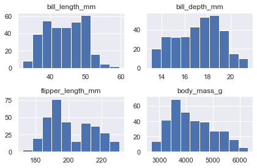

```python
df.hist()
plt.tight_layout()
plt.show()
```

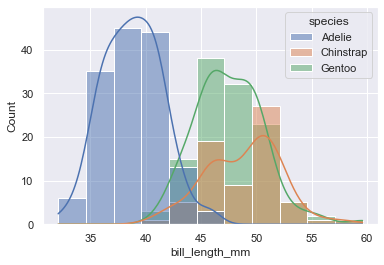

```python
sns.histplot(x='bill_length_mm', data=df, hue='species', kde=True)
plt.show()
```

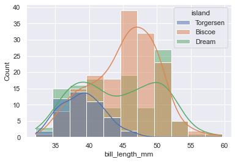

```python
sns.histplot(x='bill_length_mm', data=df, hue='island', kde=True)
plt.show()
```

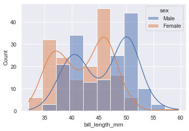

```python
sns.histplot(x='bill_length_mm', data=df, hue='sex', kde=True)
plt.show()
```

```python
df
```

|  | species | island | bill_length_mm | bill_depth_mm | flipper_length_mm | body_mass_g | sex |
| --- | --- | --- | --- | --- | --- | --- | --- |
| 0 | Adelie | Torgersen | 39.1 | 18.7 | 181.0 | 3750.0 | Male |
| 1 | Adelie | Torgersen | 39.5 | 17.4 | 186.0 | 3800.0 | Female |
| 2 | Adelie | Torgersen | 40.3 | 18.0 | 195.0 | 3250.0 | Female |
| 4 | Adelie | Torgersen | 36.7 | 19.3 | 193.0 | 3450.0 | Female |
| 5 | Adelie | Torgersen | 39.3 | 20.6 | 190.0 | 3650.0 | Male |
| ... | ... | ... | ... | ... | ... | ... | ... |
| 338 | Gentoo | Biscoe | 47.2 | 13.7 | 214.0 | 4925.0 | Female |
| 340 | Gentoo | Biscoe | 46.8 | 14.3 | 215.0 | 4850.0 | Female |
| 341 | Gentoo | Biscoe | 50.4 | 15.7 | 222.0 | 5750.0 | Male |
| 342 | Gentoo | Biscoe | 45.2 | 14.8 | 212.0 | 5200.0 | Female |
| 343 | Gentoo | Biscoe | 49.9 | 16.1 | 213.0 | 5400.0 | Male |

333 rows × 7 columns

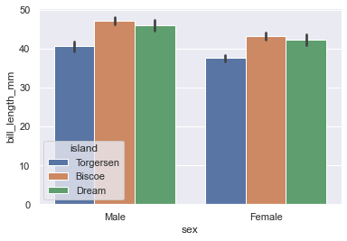

```python
sns.barplot(x='sex', y='bill_length_mm', data=df, hue='island')
plt.show()
```

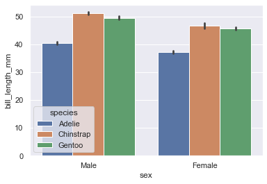

```python
sns.barplot(x='sex', y='bill_length_mm', data=df, hue='species')
plt.show()
```

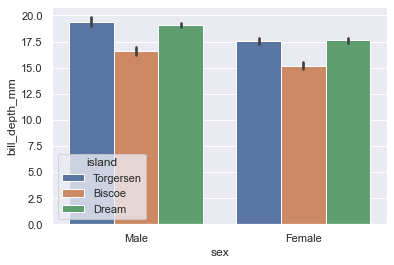

```python
sns.barplot(x='sex', y='bill_depth_mm', data=df, hue='island')
plt.show()
```

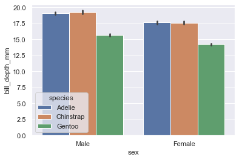

```python
sns.barplot(x='sex', y='bill_depth_mm', data=df, hue='species')
plt.show()
```

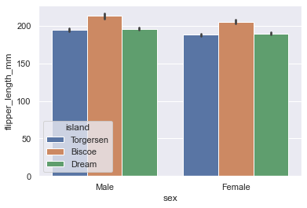

```python
sns.barplot(x='sex', y='flipper_length_mm', data=df, hue='island')
plt.show()
```

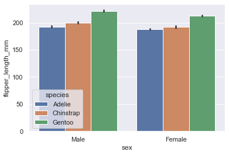

```python
sns.barplot(x='sex', y='flipper_length_mm', data=df, hue='species')
plt.show()
```

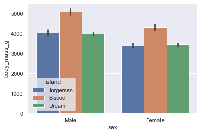

```python
sns.barplot(x='sex', y='body_mass_g', data=df, hue='island')
plt.show()
```

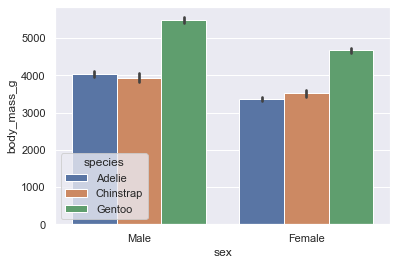

```python
sns.barplot(x='sex', y='body_mass_g', data=df, hue='species')
plt.show()
```

### Excercise 6:

Use `seaborn` to plot each of following figure. All figures must have title, label and legend.

- Use box plot to show information of each penguins feature (`bill_length_mm`, `bill_depth_mm`, `flipper_length_mm`, `body_mass_g`)
- Use violin plot to show information of each penguins feature (`bill_length_mm`, `bill_depth_mm`, `flipper_length_mm`, `body_mass_g`) split by `sex`.

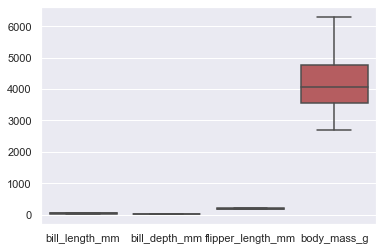

```python
sns.boxplot(data=df)
plt.show()
```

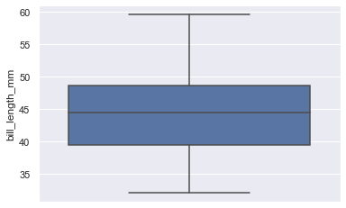

```python
sns.boxplot(y='bill_length_mm', data=df)
plt.show()
```

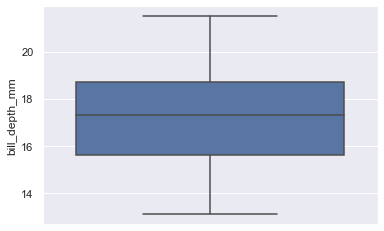

```python
sns.boxplot(y='bill_depth_mm', data=df)
plt.show()
```

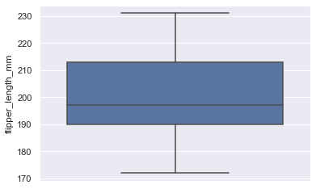

```python
sns.boxplot(y='flipper_length_mm', data=df)
plt.show()
```

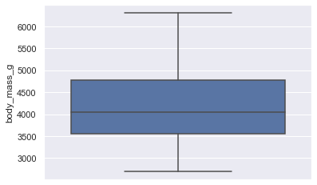

```python
sns.boxplot(y='body_mass_g', data=df)
plt.show()
```

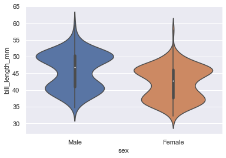

```python
sns.violinplot(x='sex', y='bill_length_mm', data=df)
plt.show()
```

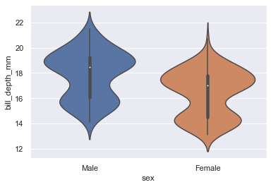

```python
sns.violinplot(x='sex', y='bill_depth_mm', data=df)
plt.show()
```

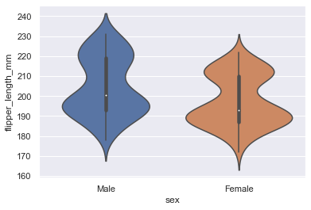

```python
sns.violinplot(x='sex', y='flipper_length_mm', data=df)
plt.show()
```

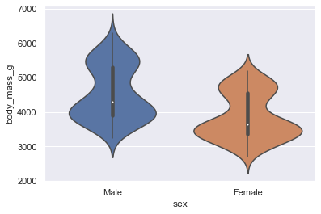

```python
sns.violinplot(x='sex', y='body_mass_g', data=df)
plt.show()
```